# Jupyter

### Pair Plot

A pair plot creates joint plots for all combinations of pairs of columns with numerical values.

`hue` is a keyword argument that takes in a column with categorical values.

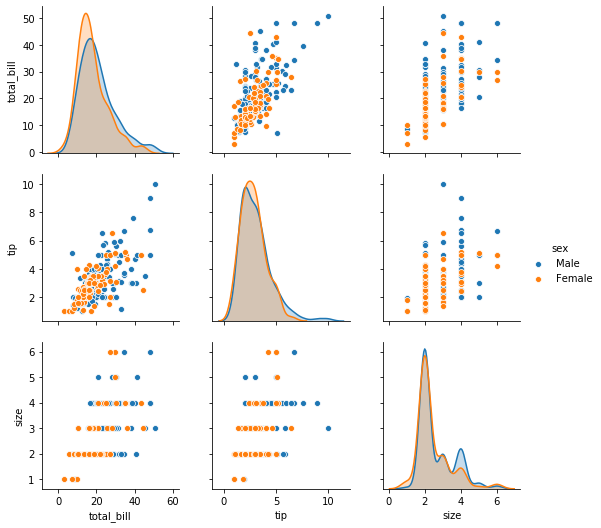

```python
sns.pairplot(tips, hue='sex')
```

### Rug Plot

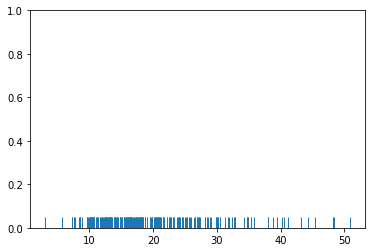

```python
sns.rugplot(tips['total_bill'])
```

## Categorical Plots

### Bar Plot

A bar plot aggregates the categorical data by mean (by default).

`estimator` is a keyword argument that takes in an aggregate function, e.g., `np.std()`.

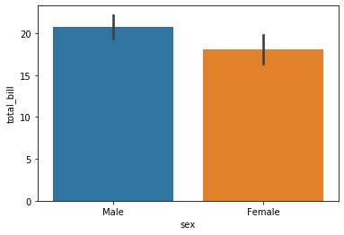

```python
sns.barplot(x='sex', y='total_bill', data=tips)
```

### Count Plot

A count plot counts the number of occurrences of a categorical variable.

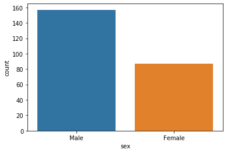

```python
sns.countplot(x='sex', data=tips)
```

### Box Plot

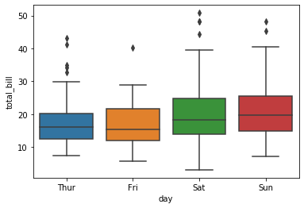

```python
sns.boxplot(x='day', y='total_bill', data=tips)
```

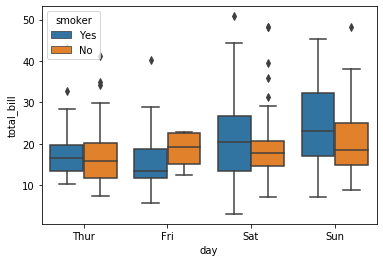

```python
sns.boxplot(x='day', y='total_bill', data=tips, hue='smoker')
```

### Violin Plot

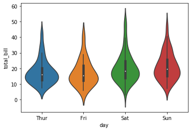

```python
sns.violinplot(x='day', y='total_bill', data=tips)
```

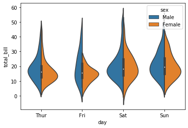

```python
sns.violinplot(x='day', y='total_bill', data=tips, hue='sex', split=True)
```

### Strip Plot

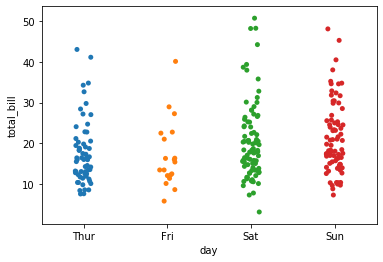

```python
sns.stripplot(x='day', y='total_bill', data=tips)
```

### Swarm Plot

A swarm plot is a combination of a violin plot and a strip plot.

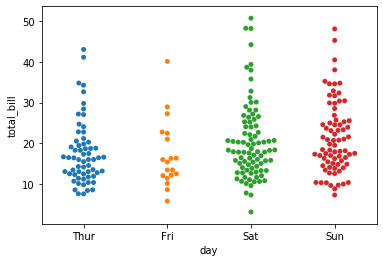

```python
sns.swarmplot(x='day', y='total_bill', data=tips)
```